# Text Suggestion Presentation

## Introduction

### Objective

- Build a predictive model of English text
- Develop an interface for our model via a Shiny application.
- When a user type text, he can see predictions for his next word

### Background

- Final task in the [Data Science Capstone](https://www.coursera.org/learn/data-science-project?specialization=jhu-data-science) to create a usable data product

### Data

- Provided by the [Data Science Capstone](https://www.coursera.org/learn/data-science-project?specialization=jhu-data-science)
- en_US.blogs.txt, en_US.news.txt, en_US.twitter.txt

## Model

- Apply N-gram to build our model
- (N-gram: a contiguous sequence of n items from a given sample of text)

### N-gram

- Train Bigram, Trigram, 5-grams and 7-gram

## Application Features

- Automatic suggestion
- Build your own model
- Generate “composition”
- Interactive selection
- Suggestion visualization

### How to use

- Type a text for suggestions for the next word. Suggested words are in the Wordcloud and the bar chart.
- Click the word cloud and the bar chart as an input
- Suggestions are automatically updated if Auto-Suggestion is selected
- Can build your model by uploading a text file.
- After you built your model, you can select to use our default model or your prediction model.
- Our application can generate an English-like composition based on your input.

## Futher Information

- Shiny application: [Text Suggestion](https://cwl286.shinyapps.io/TextSuggestion/)
- View [Source](https://github.com/cwl286/datasciencecoursera/tree/master/10DataScienceCapstone/TextSuggestion)
- View course information [(Data Science Capstone)](https://www.coursera.org/learn/data-science-project?specialization=jhu-data-science)
- Report [bug](https://github.com/cwl286/datasciencecoursera/issues)

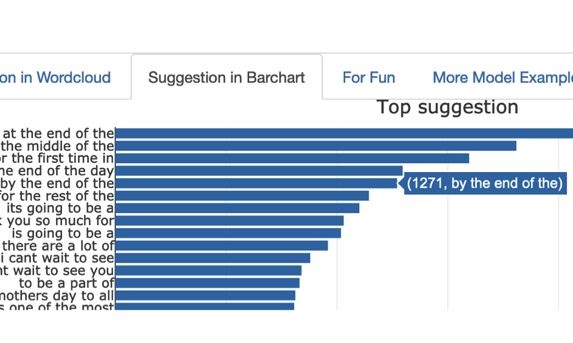

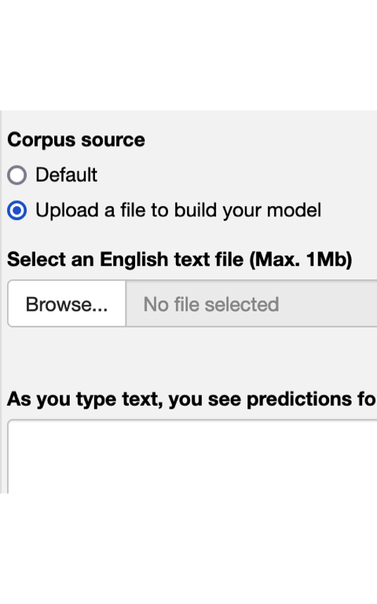